# Warbler Overlap Project - Lucy’s Warbler

Kristen Rosamond

Methods: I will use data of Parulidae warbler sightings from the eBird citizen science database. I will construct a grid over the Americas showing abundance of species at each grid square. I will use # of complete checklists for each species divided by # of total complete checklists to weight the data by effort.

Hypothesis: Parulidae warbler species overlaps differ between summer and winter.

1. Data Preparation These data were collected by numerous different observers who submitted their bird sightings to the eBird database. I downloaded the full eBird database (including all reported sightings of all species) from the eBird website.

Data description: Column 1: Global unique identifier - Unique alphanumeric code assigned to each record that stays with it through database revisions, updates, and edits.

Column 2: Last edited date - Date and time of most recent edit to the observation

Column 3: Taxonomic order - Numeric value assigned to the taxon in the eBird taxonomy

Column 4: Category - Ex. species, hybrid, slash

Column 5: Common name - Primary English common name of the taxon in the eBird taxonomy

Column 6: Scientific name - Scientific name of the taxon

Column 7: Subspecies common name - Common name of the subspecies or subspecies group in the eBird taxonomy

Column 8: Subspecies scientific name - Scientific name of the subspecies or subspecies group

Column 9: Observation count - Count of individuals made at the time of observation. If no count was made, an ‘X’ is used to indicate presence.

Column 10: Breeding Bird Atlas code - Four categories used to describe a species’ breeding status based on the ‘BREEDING BIRD ATLAS CODE’ reported on the eBird checklist: C1 – Observed; C2 – Possible; C3 – Probable; C4 – Confirmed

Column 11: Age/Sex - Age = adult, immature, or juvenile; Sex = male, female, or unknown

Column 12: Country - Country where the observation was made

Column 13: Country code - Abbreviation for country where observation was made

Column 14: State - State/province where the observation was made

Column 15: State code - Abbreviation for state where observation was made

Column 16: County - County where the observation was made

Column 17: County code - Abbreviation for county where observation was made

Column 18: IBA code - Alphanumeric code for an Important Bird Area

Column 19: BCR code - Alphanumeric code for a Bird Conservation Region

Column 20: USFWS code - Alphanumeric code for a United States Fish and Wildlife Service land holding

Column 21: Atlas block - Sampling units called blocks have been established for specific atlas projects run within eBird. Each block is coded with a 2-letter code: northwest (NW), northeast (NE), center- west (CW), center-east (CE), southwest (SW), or southeast (SE).

Column 22: Locality ID - Unique alphanumeric code for a location

Column 23: Locality type - Helps define the type of location used, as participants in eBird can plot specific locations on a map (P), choose existing locations from a map (H), or choose to submit data for a town (T), postal code (PC), county (C), or state (S). Abbreviations: State (S), County (C), Postal/Zip Code (PC), Town (T), Hotspot (H), Personal (P).

Column 24: Latitude - Latitude of the observation in decimal degrees

Column 25: Longitude - Longitude of the observation in decimal degrees

Column 26: Observation date - Date of the observation expressed as year-month-day

Column 27: Time observations started - Time observations were initiated based on the 24- hour clock (military time)

Column 28: Observer ID - Unique number associated with each eBird observer

Column 29: Sampling event identifier - Unique number associated with the sampling event (eBird checklist). Each sampling event has a unique combination of location, date, observer, and start time. A sampling event can contain one or many species, all of which share this unique identifier.

Column 30: Protocol type - Type of survey associated with this sampling event (ex. traveling count, stationary count, casual observation)

Column 31: Protocol code - Unique code used to identify type of protocol

Column 32: Project code - Designates which portal the data came through

Column 33: Duration minutes - Duration of the sampling event in minutes

Column 34: Effort Distance (km) - Distance traveled during the sampling event in kilometers

Column 35: Effort area (ha) - Area covered during the sampling event in hectares

Column 36: Number observers - Total number of observers participating in the sampling event

Column 37: All species reported - Observers answer ‘yes’ (1) to this question when they are reporting all species detected by sight and by ear to the best of their ability on a given checklist (sampling event). Observers answer ‘no’ (0) to this question when they are only reporting a selection of species from an outing, usually the highlights or unusual birds.

Column 38: Group identifier - When multiple observers participate in the same sampling event, they can share checklists. If a checklist is shared between multiple observers, it is given a GROUP ID number.

Column 39: Has media - Indicates whether a particular observation is supported by rich media stored at the Cornell Lab of Ornithology’s Macaulay Library

Column 40: Approved - The status of the record within the eBird data quality process. If “Approved”, the record is deemed acceptable. If “Not Approved” the record has been deemed unacceptable by the review processes.

Column 41: Reviewed - “Not Reviewed” means the record passed through the automated filters without problems, that the species, date, and count were within expected levels, and that the record has otherwise not been reviewed by a reviewer. “Reviewed” means that the record triggered a higher-level review process, either through an automated or manual process, and that it was vetted by a regional editor. (1 = yes; 0 = no).

Column 42: Reason - The reason the record was “Not Approved” -> “Species—Introduced/Exotic”

Check and clean data:

Install all necessary packages for data cleaning: `auk` package.

```r
library(auk)
```

I loaded the auk package, which filters and pre-processes eBird data. I then defined a variable for the path to the folder in my external hard drive that contains my downloaded eBird data.

```r
ebd_dir <- "/Volumes/MyPassport/WarblerOverlap"
```

I defined file paths for the raw eBird data that I already have saved, as well as for the cleaned eBird data file that I am about to create. The auk_clean function drops unnecessary or problematic records from the raw data file, including rows containing special characters or blank columns.

```r
f <- file.path(ebd_dir, "data/raw_data/ebd_relAug-2018.txt")
f_clean <- file.path(ebd_dir, "data/raw_data/ebd_relAug-2018_cleaned.txt")
#auk_clean(f, f_out = f_clean, remove_text = TRUE)
```

Next, I defined file paths for the eBird sampling event data, which is a separate file from the main eBird raw data file. I will also clean the sampling event data file using auk_clean.

```r
f_sampling <- file.path(ebd_dir, "data/raw_data/ebd_sampling_relAug-2018.txt")
f_sampling_clean <- file.path(ebd_dir, "data/raw_data/ebd_sampling_relAug-2018_cleaned.txt")
#auk_clean(f, f_out = f_sampling_clean, remove_text = TRUE)
```

Next, I defined paths to the eBird data file and the sampling event data file. I then used the auk_ebd function to create an object referencing the files.

```r
f_in_ebd <- file.path(ebd_dir, "data/cleaned_data/ebd_relAug-2018_cleaned.txt") #define paths to ebd file
f_in_sampling <- file.path(ebd_dir, "data/cleaned_data/ebd_sampling_relAug-2018_cleaned.txt") #define paths to sampling file
auk_ebd(file = f_in_ebd, file_sampling = f_in_sampling) #create an object referencing the file
```

```
## Input
##   EBD: /Volumes/MyPassport/WarblerOverlap/data/cleaned_data/ebd_relAug-2018_cleaned.txt
##   Sampling events: /Volumes/MyPassport/WarblerOverlap/data/cleaned_data/ebd_sampling_relAug-2018_cleaned.txt
##
## Output
##   Filters not executed
##
## Filters
##   Species: all
##   Countries: all
##   States: all
##   Spatial extent: full extent
##   Date: all
##   Start time: all
##   Last edited date: all
##   Protocol: all
##   Project code: all
##   Duration: all
##   Distance travelled: all
##   Records with breeding codes only: no
##   Complete checklists only: no
```

3. Filtering and selecting I defined filters for the data in both the eBird data file and the sampling event data file. I filtered out data from just one species (Lucy’s warbler) over one year 7/15/17-7/15/18 to have a smaller amount of data to work with. auk_complete filters out incomplete checklists from the data. A complete checklist means that the observer reported all bird species that they saw or heard.

```r
ebd_filtersTEST <- auk_ebd(f_in_ebd, f_in_sampling) %>%
  auk_species(c("Lucy’s warbler")) %>%
  auk_date(c("2017-07-15", "2018-07-15")) %>% #filter dates
  auk_complete()
ebd_filtersTEST
```

```
## Input
##   EBD: /Volumes/MyPassport/WarblerOverlap/data/cleaned_data/ebd_relAug-2018_cleaned.txt
##   Sampling events: /Volumes/MyPassport/WarblerOverlap/data/cleaned_data/ebd_sampling_relAug-2018_cleaned.txt
##
## Output
##   Filters not executed
##
## Filters
##   Species: Oreothlypis luciae
##   Countries: all
##   States: all
##   Spatial extent: full extent
##   Date: 2017-07-15 - 2018-07-15
##   Start time: all
##   Last edited date: all
##   Protocol: all
##   Project code: all
##   Duration: all
##   Distance travelled: all
##   Records with breeding codes only: no
##   Complete checklists only: yes
```

I defined paths where the new filtered data will be saved. auk_filter compiles all of the filters that I defined above into a script that will filter the data.

```r
f_out_ebd <- "data/cleaned_data/ebd_Parulidae.txt"
f_out_sampling <- "data/cleaned_data/ebd_Parulidae_sampling.txt"
#ebd_filtered <- auk_filter(ebd_filtersTEST, file = f_out_ebd,
                           #file_sampling = f_out_sampling)
```

Next, I read in the filtered eBird data file and view it in R.

```r
f_out_ebd <- "data/cleaned_data/ebd_ParulidaeTEST.txt"
f_out_sampling <- "data/cleaned_data/ebd_Parulidae_samplingTEST.txt"
#ebd_filtered <- auk_filter(ebd_filtersTEST, file = f_out_ebd,
                          #file_sampling = f_out_sampling)
ebd <- read_ebd(f_out_ebd)
```

I filtered the data further to remove any columns of data that I know I will not need. I removed the following columns: global unique identifier, taxonomic order, breeding bird atlas category, age/sex, iba code, bcr code, usfws code, atlas block, locality ID, locality type, sampling event identifier, protocol code, project code, effort area (ha), group identifier, and reason. I saved this final filtered data as a new CSV file.

```r
ebd_filtered_subset<-subset(ebd,select=-c(global_unique_identifier,taxonomic_order,breeding_bird_atlas_category,age_sex,iba_code,bcr_code,usfws_code,atlas_block,locality_id,locality_type,sampling_event_identifier,protocol_code,project_code,effort_area_ha,group_identifier,reason))
write.csv(ebd_filtered_subset,"ebd_filtered_subset.csv")
```

2. Data exploration Install all necessary packages for data exploration: `data.table` package and `tidyverse` package.

```r
library(data.table)
library(tidyverse)
```

Load in Lucy’s warbler data file as a data frame and summarize data.

```r
Lucys_warbler_data<-fread("data/cleaned_data/ebd_filtered_subset.csv",data.table=FALSE)
summary(Lucys_warbler_data)
```

```
##        V1        checklist_id       last_edited_date     category
##  Min.   :    1   Length:10611       Length:10611       Length:10611
##  1st Qu.: 2654   Class :character   Class :character   Class :character
##  Median : 5306   Mode  :character   Mode  :character   Mode  :character
##  Mean   : 5306
##  3rd Qu.: 7958
##  Max.   :10611
##
##  common_name        scientific_name    observation_count
##  Length:10611       Length:10611       Length:10611
##  Class :character   Class :character   Class :character
##  Mode  :character   Mode  :character   Mode  :character
##
##
##
##
##  breeding_bird_atlas_code   country          country_code
##  Length:10611             Length:10611       Length:10611
##  Class :character         Class :character   Class :character
##  Mode  :character         Mode  :character   Mode  :character
##
##
##
##
##     state            state_code           county
##  Length:10611       Length:10611       Length:10611
##  Class :character   Class :character   Class :character
##  Mode  :character   Mode  :character   Mode  :character
##
##
##
##
##  county_code           latitude       longitude       observation_date
##  Length:10611       Min.   :16.78   Min.   :-122.50   Length:10611
##  Class :character   1st Qu.:31.61   1st Qu.:-111.83   Class :character
##  Mode  :character   Median :32.31   Median :-111.00   Mode  :character
##                     Mean   :32.89   Mean   :-111.25
##                     3rd Qu.:33.93   3rd Qu.:-110.78
##                     Max.   :38.88   Max.   : -96.07
##
```

[output cut: 9 more lines]

```
##  Min.   :   1.0   Min.   : 0.000     Min.   : 1.000   Mode:logical
##  1st Qu.:  50.0   1st Qu.: 0.966     1st Qu.: 1.000   TRUE:10611
##  Median :  98.0   Median : 1.786     Median : 1.000
##  Mean   : 117.6   Mean   : 2.629     Mean   : 2.367
##  3rd Qu.: 160.0   3rd Qu.: 3.219     3rd Qu.: 2.000
##  Max.   :1202.0   Max.   :74.030     Max.   :56.000
##  NA's   :38       NA's   :1650       NA's   :8
##  has_media        approved        reviewed
##  Mode :logical   Mode :logical   Mode :logical
##  FALSE:10106     FALSE:4         FALSE:10320
##  TRUE :505       TRUE :10607     TRUE :291
##
##
##
##
```

Table showing the number of Lucy’s warbler individuals by country.

```r
Lucys_warbler_country_table<-table(Lucys_warbler_data$common_name, Lucys_warbler_data$country)
Lucys_warbler_country_table
```

```
##
##                  Mexico United States
##   Lucy's Warbler    165         10446
```

Table showing the number of Lucy’s warbler individuals by county.

```r
Lucys_warbler_county_table<-table(Lucys_warbler_data$common_name, Lucys_warbler_data$county)
Lucys_warbler_county_table
```

```
##
##                  Apache Bernalillo Brewster Catron Clark Cochise Coconino
##   Lucy's Warbler     11        162       50     13   482     708      171
##
##                  Culberson Dona Ana Eddy El Paso Garfield Gila Graham
##   Lucy's Warbler         1       33   47      49       14  137     34
##
##                  Grand Grant Greenlee Hidalgo Hudspeth Imperial Inyo Kane
##   Lucy's Warbler    56    78       22      16        6        7   29    8
##
##                  La Paz Lincoln Los Angeles Luna Maricopa Mohave Monterey
##   Lucy's Warbler     77      19          57   10     1034    118        4
##
##                  Montezuma Navajo  Nye Orange Pima Pinal Riverside
##   Lucy's Warbler        13      6   39     19 3073   298        31
##
##                  San Bernardino San Diego San Francisco San Juan
##   Lucy's Warbler             36        14            25       20
##
##                  San Luis Obispo Sandoval Santa Barbara Santa Cruz Sierra
##   Lucy's Warbler               6        2            22       2151     61
##
##                  Socorro Valencia Washington Yavapai Yuma
##   Lucy's Warbler      69       13        236     846   13
```

Bar graph showing countries with recorded Lucy’s warbler sightings.

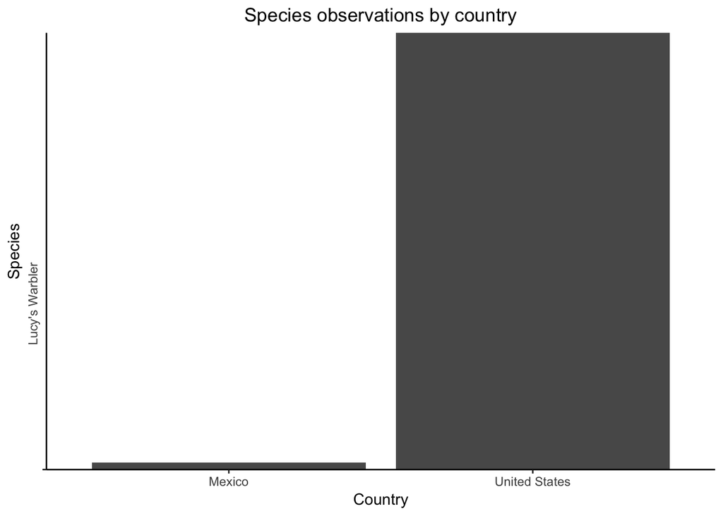

```r
ggplot(data=Lucys_warbler_data,mapping = aes(x = country, y = common_name)) +
  labs(title = "Species observations by country", x = "Country",y = "Species") +
  theme_classic() +
  theme(plot.title = element_text(hjust = 0.5),axis.text.y = element_text(angle=90,hjust=-1.5)) +
  geom_bar(stat="identity")
```

Bar graph showing states with recorded Lucy’s warbler sightings.

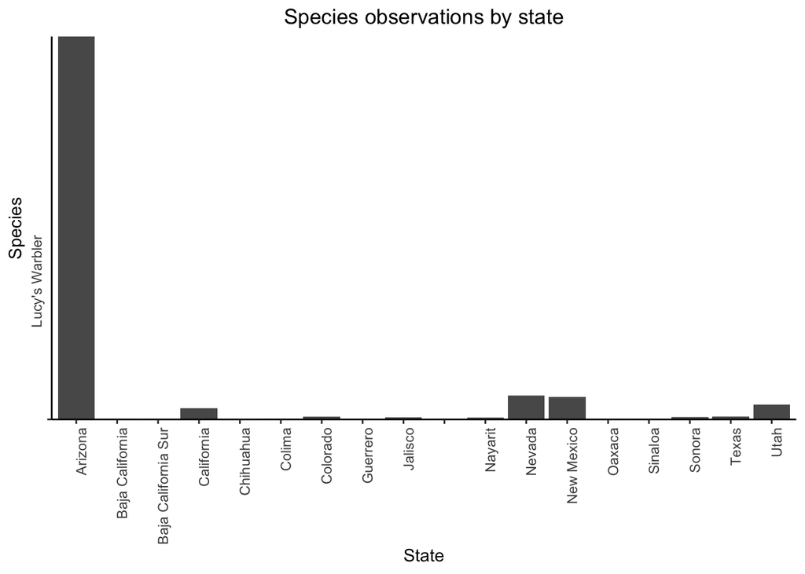

```r
ggplot(data=Lucys_warbler_data,mapping = aes(x = state, y = common_name)) +
    labs(title = "Species observations by state", x = "State",y = "Species") +
  theme_classic() +
  theme(plot.title = element_text(hjust = 0.5)) + #reposition title
  theme(axis.text.x = element_text(angle = 90, hjust = 1),axis.text.y = element_text(angle=90,hjust=-1)) + #make x-axis labels vertical
  geom_bar(stat="identity")
```

Bar graph showing counties with recorded Lucy’s warbler sightings.

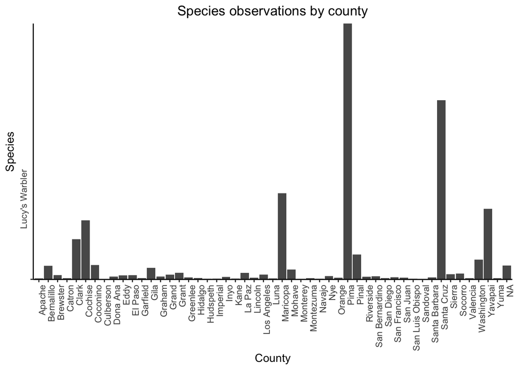

```r
ggplot(data=Lucys_warbler_data,mapping = aes(x = county, y = common_name)) +
    labs(title = "Species observations by county", x = "County",y = "Species") +
  theme_classic() +
  theme(plot.title = element_text(hjust = 0.5)) + #reposition title
  theme(axis.text.x = element_text(angle = 90, hjust = 1),axis.text.y = element_text(angle=90,hjust=-.85)) + #make x-axis and y-axis labels vertical and reposition them
  geom_bar(stat="identity")
```

Visualize Lucy’s warblers distribution on a global scale.

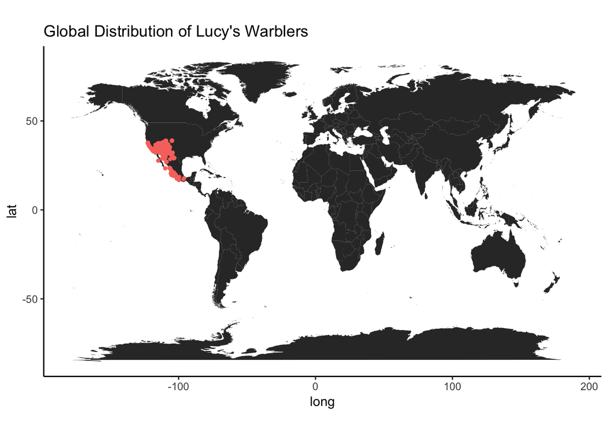

```r
world<-map_data("world") #create a data frame of global map data
world_map<-ggplot() + geom_polygon(data = world, aes(x=long, y = lat, group = group)) +
  coord_fixed(1.3)
  labs <- data.frame(
  long = Lucys_warbler_data$longitude,
  lat = Lucys_warbler_data$latitude,
  stringsAsFactors = FALSE
  )
world_map +
  geom_point(data = Lucys_warbler_data, aes(x = longitude, y = latitude,color=common_name), size = 1, show.legend=FALSE) + #add points, remove legend
  ggtitle("Global Distribution of Lucy's Warblers") + #add title
  theme_classic() #add classic theme (has no gridlines)
```

Table showing the number of Lucy’s warbler individuals by US state.

```r
Lucys_warbler_USA <- subset(Lucys_warbler_data, country_code == "US") #create new data frame with subset of data containing only warblers in USA
Lucys_warbler_state_table<-table(Lucys_warbler_USA$common_name, Lucys_warbler_USA$state)
Lucys_warbler_state_table
```

```
##
##                  Arizona California Colorado Nevada New Mexico Texas Utah
##   Lucy's Warbler    8699        250       58    540        506    61  332
```

Visualize Lucy’s warblers distribution in the United States.

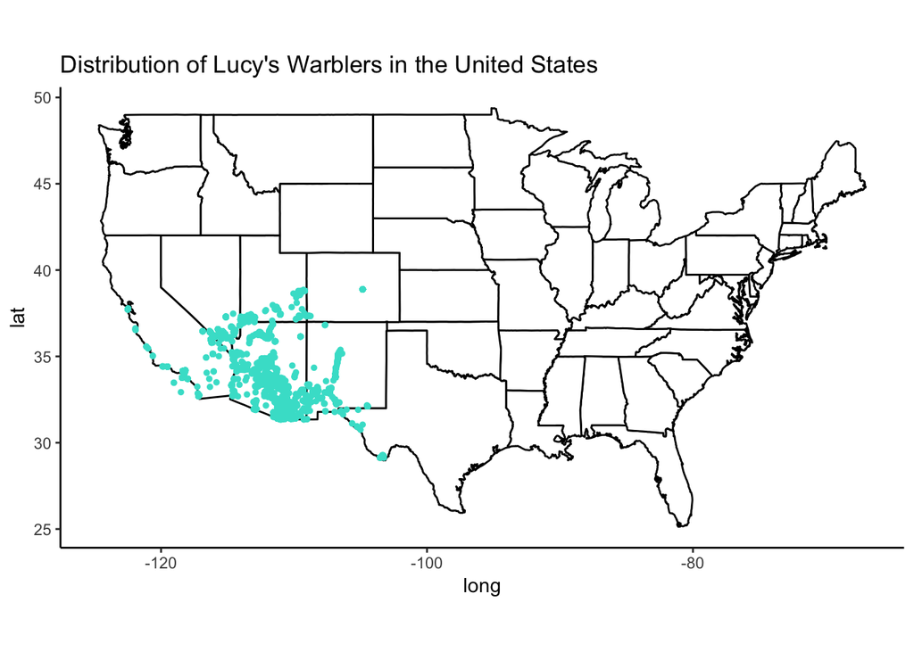

```r
states<-map_data("state") #create data frame of polygons that show state boundaries
world_map<-ggplot() + geom_polygon(data = states, aes(x=long, y = lat, group = group),color="black",fill="white") +
  coord_fixed(1.3)
  labs <- data.frame(
  long = Lucys_warbler_USA$longitude,
  lat = Lucys_warbler_USA$latitude,
  stringsAsFactors = FALSE
  )
world_map +
  geom_point(data = Lucys_warbler_USA, aes(x = longitude, y = latitude,color=common_name), color="turquoise",size = 1,show.legend=FALSE) + #add points, change color to turquoise, remove legend
  ggtitle("Distribution of Lucy's Warblers in the United States") + #add title
  theme_classic() #add classic theme (has no gridlines)
```

Table showing the number of Lucy’s warbler individuals by county in Arizona.

```r
Lucys_warbler_AZ <- subset(Lucys_warbler_data, state_code == "US-AZ") #create new data frame with subset of data containing only warblers in Arizona
Lucys_warbler_AZ_table<-table(Lucys_warbler_AZ$common_name, Lucys_warbler_AZ$county)
Lucys_warbler_AZ_table
```

```
##
##                  Apache Cochise Coconino Gila Graham Greenlee La Paz
##   Lucy's Warbler     11     708      171  137     34       22     77
##
##                  Maricopa Mohave Navajo Pima Pinal Santa Cruz Yavapai Yuma
##   Lucy's Warbler     1034    118      6 3073   298       2151     846   13
```

Visualize Lucy’s warbler individuals in state of Arizona with county boundaries visible. Zoom in on Arizona and look at counties. First get a state data.frame with a single state for the outline of AZ. Then create a counties data.frame of the counties in AZ.

```r
az_df <- subset(states, region == "arizona")
```

Plot the state and use `theme_void` to get rid of grid lines, axes, etc.

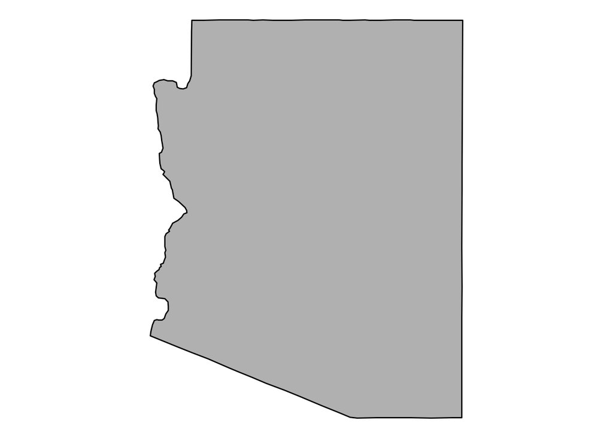

```r
counties <- map_data("county")
az_county <- subset(counties, region == "arizona")
az_base <- ggplot(data = az_df, mapping = aes(x = long, y = lat, group = group)) +
  coord_fixed(1.3) +
  geom_polygon(color = "black", fill = "gray")
az_base + theme_void()
```

Add points, county lines, and title.

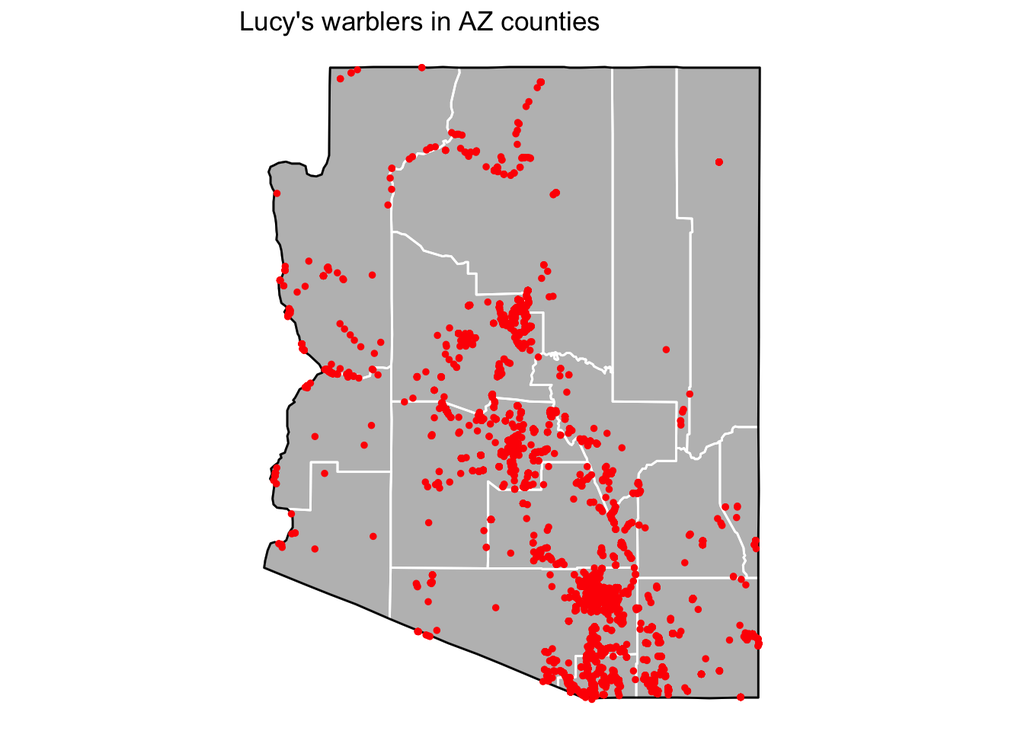

```r
az_base + theme_minimal() +
  geom_polygon(data = az_county, fill = NA, color = "white") +
  geom_polygon(color = "black", fill = NA) +
  geom_point(data = Lucys_warbler_AZ, aes(x = longitude, y = latitude,color=common_name), color="red",size = 1,show.legend=FALSE,inherit.aes=FALSE) + theme_void() + ggtitle("Lucy's warblers in AZ counties")
```